# Loans Data Exploration

### Talk about some of the relationships you observed in this part of the investigation. How did the feature(s) of interest vary with other features in the dataset?

- The density of defaulted loans increases at high rates, and so are loans at risk, while the density of current and completed loans is higher at small rates.
- Low loan amounts have high rates with large standard deviation, while very large amounts have small rates with low standard deviation.
- Current loans have higher income and higher amounts than other statuses.
- In general defaulted loans and loans at risk had lower prosper score than completed and current loans.
- The highest ratio of defaulted loans are for borrowers with "Unavailable" employment status, then come the "Not employed" and "Retired". So it is better to check the borrower's employment status.

### Did you observe any interesting relationships between the other features (not the main feature(s) of interest)?

- A strong positive correlation between the loan amount and the monthly payment.
- A negative correlation between borrower APR and prosper score.
- For low income borrowers, count of loans decreases with loan amount increases, but they are equally distributed for higher income.
- There is a noticed increase in loans amounts for the last two years.

## Multivariate Exploration

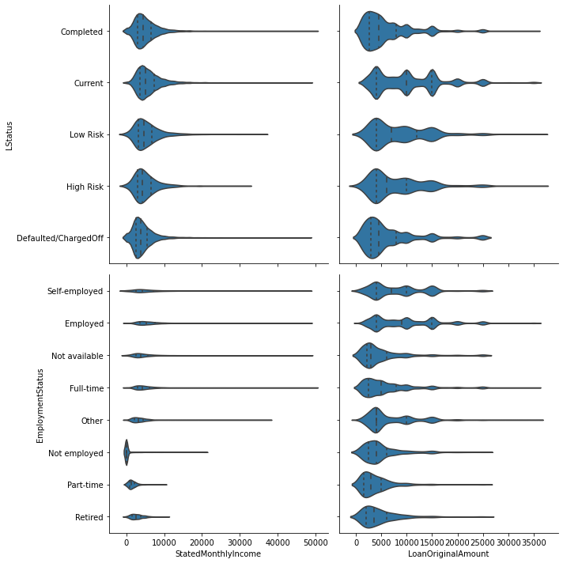

```python
#First will start by a grid for different variables
g = sb.PairGrid(data = df[df.StatedMonthlyIncome <50000], x_vars = ['StatedMonthlyIncome', 'LoanOriginalAmount'],
                y_vars = ['LStatus','EmploymentStatus'], height=5)
g.map(sb.violinplot, inner = 'quartile')

plt.tight_layout();
```

- For all loan statuses, the median and quartiles of monthly income are nearly the same, however the distribution of loan amounts differs. The completed and defaulted loans (closed loans) are similarly distributed, while the open loans tend to have more values.
- Not employed borrowers have a large count of zero income, however their loans amounts vary with median of about 4k. Employed borrowers have the largest median loan amount.

```python
df.EmploymentStatus.unique()
```

```
array(['Self-employed', 'Employed', 'Not available', 'Full-time', 'Other',
       'Not employed', 'Part-time', 'Retired'], dtype=object)
```

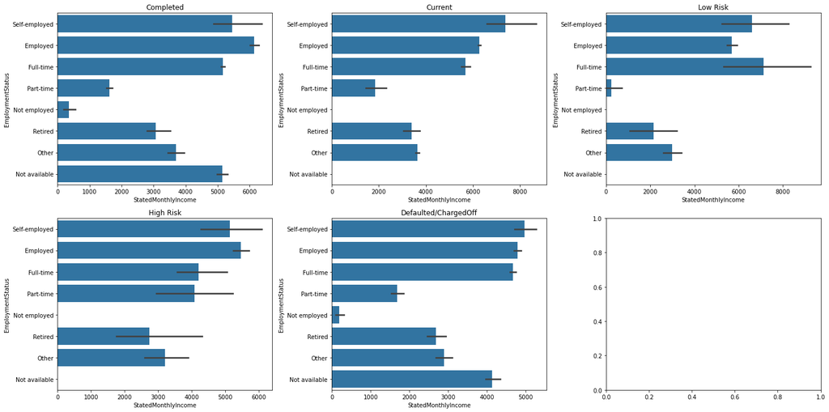

```python
# I am interested now to see the mean income for emplyment status by loan status
#Now let's see the loan status distribution through years
plt.subplots(2,3,figsize = (20,10))
Emp_order = ['Self-employed', 'Employed', 'Full-time', 'Part-time',
       'Not employed', 'Retired', 'Other', 'Not available']
for i in range(5):   #index of the status list
    plt.subplot(2,3,i+1)
    df_sub = df[df.LStatus == lstatus[i]]
    sb.barplot(data = df_sub, y = 'EmploymentStatus', x = 'StatedMonthlyIncome', color = clr, order = Emp_order)
    plt.title(lstatus[i])
    plt.tight_layout()
```

#### There is nothing to notice from this diagram, except that currently there is no income stated for loans without employment status or with not employed status.

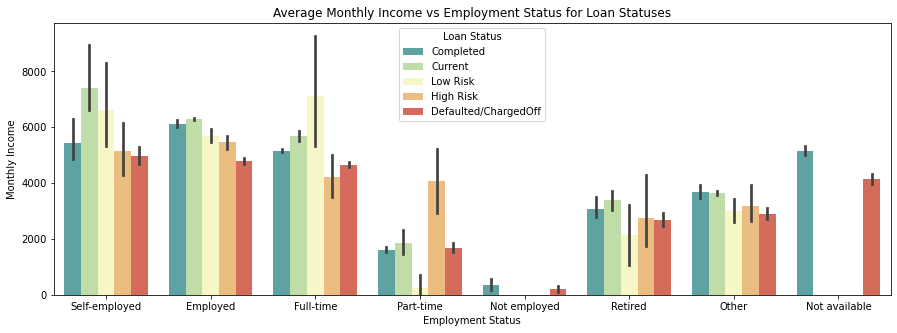

```python
#Lets try clustered barplot
plt.figure(figsize = (15,5))
sb.barplot(data = df, x= 'EmploymentStatus', y = 'StatedMonthlyIncome', hue = 'LStatus', hue_order = lstatus,
           order = Emp_order, palette = 'Spectral_r')
plt.title('Average Monthly Income vs Employment Status for Loan Statuses')
plt.legend( title = 'Loan Status')
plt.xlabel('Employment Status')
plt.ylabel('Monthly Income');
```

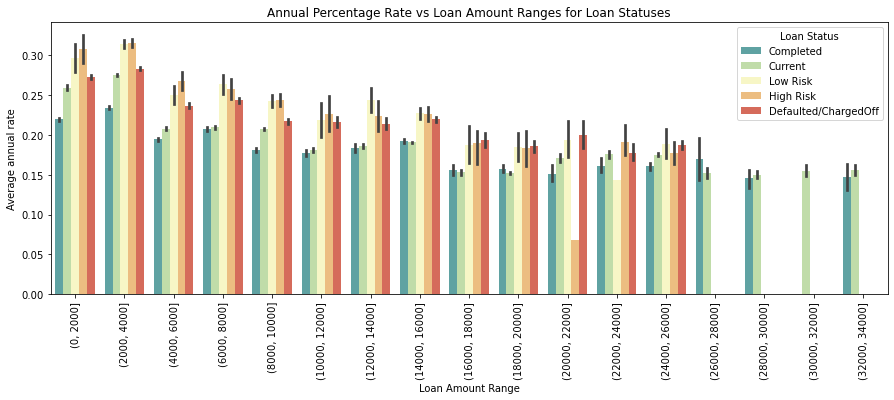

```python
# Now we want to check the relation of APR, categorized loan amount with the loan status
plt.figure(figsize = (15,5))
sb.barplot(data = df, x= 'AmountRange', y = 'BorrowerAPR', hue = 'LStatus', hue_order = lstatus,
            palette = 'Spectral_r')
plt.title('Annual Percentage Rate vs Loan Amount Ranges for Loan Statuses')
plt.legend( title = 'Loan Status')
plt.xlabel('Loan Amount Range')
plt.ylabel('Average annual rate')
plt.xticks(rotation = 90);
```

#### For all loan amounts, defaulted loans have higher APR than completed ones. For loan amounts more than 26k, there are no defaulted loans. This also applies for loans at risk in comparison with curent loans for most loan amounts.

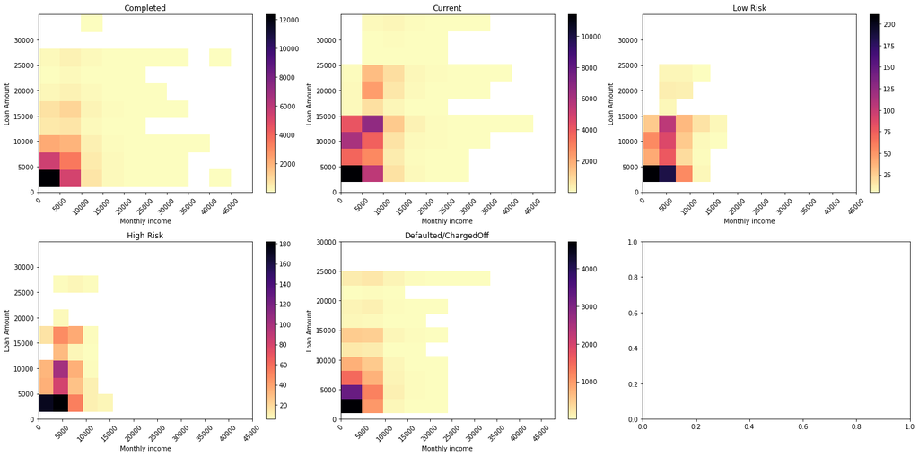

```python
#And now lets plot the loan amount vs income for loan statuses. I cannot use a scattered diagram for this large amount of data, so I will show a heat map for each status
plt.subplots(2,3,figsize = (20,10))
xt = np.arange(0, 50000, 5000)
yt = np.arange(0, 35000, 5000)
for i in range(5):   #index of the status list
    plt.subplot(2,3,i+1)
    df_sub = df[df.LStatus == lstatus[i]]
    plt.hist2d(data = df_sub[df_sub.StatedMonthlyIncome <=50000], x= 'StatedMonthlyIncome', y = 'LoanOriginalAmount' ,
               cmin=5, cmap = 'magma_r' )
    plt.colorbar()
    plt.xlabel('Monthly income')
    plt.ylabel('Loan Amount')
    plt.xticks(xt, rotation = 45)
    plt.yticks (yt)
    plt.tight_layout()
    plt.title (lstatus[i]);
```

#### Since most incomes are below 15000, I would only show those to get more insight.

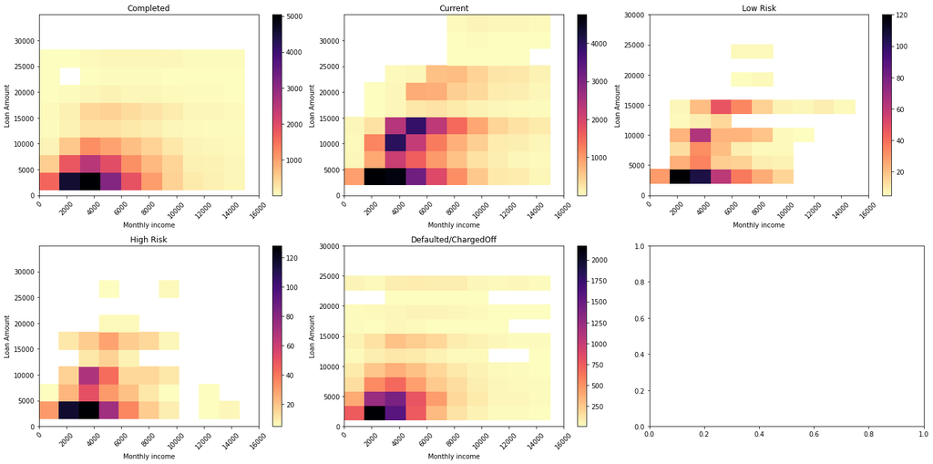

```python
plt.subplots(2,3,figsize = (20,10))
xt = np.arange(0, 17000, 2000)
yt = np.arange(0, 35000, 5000)
for i in range(5):   #index of the status list
    plt.subplot(2,3,i+1)
    df_sub = df[df.LStatus == lstatus[i]]
    plt.hist2d(data = df_sub[df_sub.StatedMonthlyIncome <=15000], x= 'StatedMonthlyIncome', y = 'LoanOriginalAmount' ,
               cmin=5, cmap = 'magma_r' )
    plt.colorbar()
    plt.xlabel('Monthly income')
    plt.ylabel('Loan Amount')
    plt.xticks(xt, rotation = 45)
    plt.yticks (yt)
    plt.tight_layout()
    plt.title (lstatus[i]);
```

```
- Most completed loans are in the rectangle from 0 to income: 9000 and loan amount to 10000.
- Most of current loans lie in ranges from 0 to income 10000 and to loan amount of 25000.
- Low risk are in the range from 0 to income of 9000 and to loan amount of 15000.
- High risk are in the range from 0 to income 7000 and loan amount of 18000.
- Defaulted loans are concentrated in the range of income up to 6000 and amount up to 8000.
```

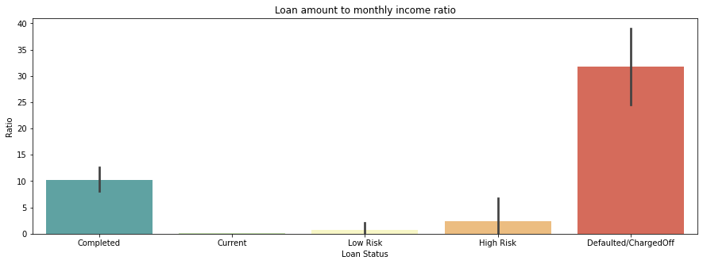

```python
#To get more insight, I'll calculate the ratio between of loan amount to monthly income and plot it against the loan status
plt.figure(figsize=(15,5))
df['LoanIncomeRatio'] = df.MonthlyLoanPayment/df.StatedMonthlyIncome
#Excluded zero income  to avoid division errors
sb.barplot(data = df[df.StatedMonthlyIncome!=0 ], x = 'LStatus', y='LoanIncomeRatio', order = lstatus, palette = 'Spectral_r')
plt.xlabel('Loan Status')
plt.ylabel('Ratio')
plt.title('Loan amount to monthly income ratio');
```

## > Apparently the ratio of monthly payment to the monthly income is very high for defaulted loans, and the good news is that this ratio is much less in current open loans, with the risk increases when this ratio increases.

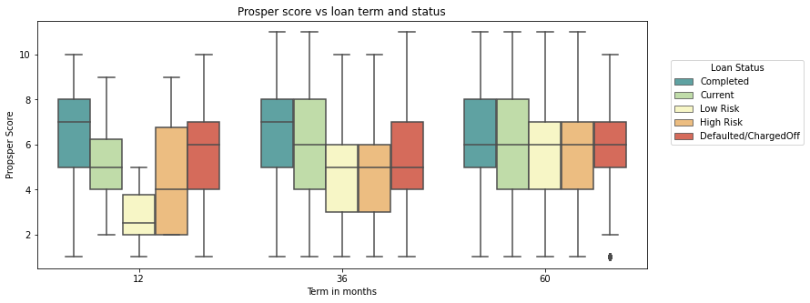

```python
#Now loan to income ratio vs the term and loan status
plt.figure(figsize=(12,5))
sb.boxplot(data = df,x ='Term', hue = 'LStatus', y='ProsperScore', hue_order = lstatus, palette = 'Spectral_r')
plt.xlabel('Term in months')
plt.ylabel('Propsper Score')
plt.title('Prosper score vs loan term and status')
plt.legend(title = 'Loan Status', loc=(1.04,0.5));
```

- One year loans have different prosper scores for loan statuses: Apparantly the prosper scores of defaulted loans are less than those of completed ones, similarly the high risk loans have less scores than current. But what the current scores are less than defaulted ones.
- In three years loans, completed and current loans have higher scores than defaulted and at risk loans.
- In five year loans, the median of the score is nearly the same for all statuses, with higher distribution for completed and current loans.

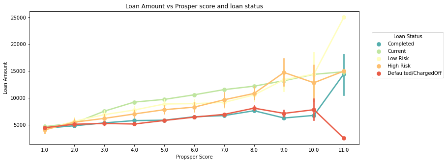

```python
#Now loan to income ratio vs the term and loan status
plt.figure(figsize=(12,5))
sb.pointplot(data = df,x ='ProsperScore', hue = 'LStatus', y='LoanOriginalAmount', hue_order = lstatus, palette = 'Spectral_r')
plt.ylabel('Loan Amount')
plt.xlabel('Propsper Score')
plt.title('Loan Amount vs Prosper score and loan status')
plt.legend(title = 'Loan Status', loc=(1.04,0.5));
```

### Talk about some of the relationships you observed in this part of the investigation. Were there features that strengthened each other in terms of looking at your feature(s) of interest?

- For all loan amounts, defaulted loans have higher APR than completed ones.
- For all loan statuses, the median and quartiles of monthly income are nearly the same, however the distribution of loan amounts differs. The loan amounts of completed and defaulted loans (closed loans) are similarly distributed, while the open loans tend to have more values.
- The ratio of monthly loan payment to the monthly income is very high for defaulted loans, and the good news is that this ratio is much less in current open loans, with the risk increases when this ratio increases.

### Were there any interesting or surprising interactions between features?

> At the end of your report, make sure that you export the notebook as an html file from the `File > Download as... > HTML` menu. Make sure you keep track of where the exported file goes, so you can put it in the same folder as this notebook for project submission. Also, make sure you remove all of the quote-formatted guide notes like this one before you finish your report!

```python
df.to_csv('cleaned_loans.csv', index=False)
```